# DATA CLUSTERING SPOTIFY 2018

Następnie skaluję swoje dane, po czym sprawdzam, jak prezentują się na wykresie.

```
##                                               danceability     energy
## 1. Drake - God's Plan                            0.2864115 -1.4480190
## 2. XXXTENTACION - SAD!                           0.1795985 -0.3175081
## 3. Post Malone - rockstar (feat. 21 Savage)     -0.9877154 -0.8551901
## 4. Post Malone - Psycho (feat. Ty Dolla $ign)    0.1719690 -0.6897495
## 5. Drake - In My Feelings                        0.9044012 -0.2278944
## 6. Post Malone - Better Now                     -0.2781717 -0.6621761
## 7. Cardi B - I Like It                           0.7594407  0.4614414
## 8. Calvin Harris - One Kiss (with Dua Lipa)      0.5687031  1.3989382
## 9. Dua Lipa - IDGAF                              0.9120307 -0.7931499
## 10. Marshmello - FRIENDS                        -0.6901648  1.5230187
##                                                       key    loudness
## 1. Drake - God's Plan                          0.45424291 -1.98773955
## 2. XXXTENTACION - SAD!                         0.72624466  0.44872319
## 3. Post Malone - rockstar (feat. 21 Savage)   -0.08976058 -0.23197871
## 4. Post Malone - Psycho (feat. Ty Dolla $ign)  0.72624466 -1.31266329
## 5. Drake - In My Feelings                     -1.17776755 -0.08739987
## 6. Post Malone - Better Now                    1.27024815 -0.09302551
## 7. Cardi B - I Like It                        -0.08976058  0.94490425
## 8. Calvin Harris - One Kiss (with Dua Lipa)    0.99824640  1.37132742
## 9. Dua Lipa - IDGAF                            0.45424291 -0.16728390
## 10. Marshmello - FRIENDS                       0.99824640  1.85288182
##                                                     mode speechiness
## 1. Drake - God's Plan                          0.8294372 -0.06284500
## 2. XXXTENTACION - SAD!                         0.8294372  0.28156360
## 3. Post Malone - rockstar (feat. 21 Savage)   -1.1935804 -0.24652959
## 4. Post Malone - Psycho (feat. Ty Dolla $ign)  0.8294372  0.01369024
## 5. Drake - In My Feelings                      0.8294372  0.09022549
## 6. Post Malone - Better Now                    0.8294372 -0.67130020
## 7. Cardi B - I Like It                        -1.1935804  0.12849311
## 8. Calvin Harris - One Kiss (with Dua Lipa)   -1.1935804 -0.05327810
## 9. Dua Lipa - IDGAF                            0.8294372 -0.20347852
## 10. Marshmello - FRIENDS                      -1.1935804 -0.62346567
##                                               acousticness
## 1. Drake - God's Plan                          -0.73547833
## 2. XXXTENTACION - SAD!                          0.28196281
## 3. Post Malone - rockstar (feat. 21 Savage)    -0.35620089
## 4. Post Malone - Psycho (feat. Ty Dolla $ign)   1.73932957
## 5. Drake - In My Feelings                      -0.61916055
## 6. Post Malone - Better Now                     0.71645725
```

[output cut: 22 more lines]

```
## 7. Cardi B - I Like It                         0.80310882  0.5606275
## 8. Calvin Harris - One Kiss (with Dua Lipa)    0.52175369  0.1420274
## 9. Dua Lipa - IDGAF                            0.12397574 -0.7944226
## 10. Marshmello - FRIENDS                       0.24039856 -0.8621056
##                                               duration_ms
## 1. Drake - God's Plan                         -0.15581375
## 2. XXXTENTACION - SAD!                        -0.96482911
## 3. Post Malone - rockstar (feat. 21 Savage)    0.32344167
## 4. Post Malone - Psycho (feat. Ty Dolla $ign)  0.40575043
## 5. Drake - In My Feelings                      0.31789277
## 6. Post Malone - Better Now                    0.65137696
## 7. Cardi B - I Like It                         1.20434284
## 8. Calvin Harris - One Kiss (with Dua Lipa)    0.24095795
## 9. Dua Lipa - IDGAF                            0.31844266
## 10. Marshmello - FRIENDS                      -0.06463175
```

[figure not shown]

```
##   danceability         energy             key              loudness
##  Min.   :-3.4978   Min.   :-2.5027   Min.   :-1.44977   Min.   :-2.49292
##  1st Qu.:-0.6177   1st Qu.:-0.6691   1st Qu.:-0.97377   1st Qu.:-0.54730
##  Median : 0.1262   Median : 0.1306   Median :-0.08976   Median : 0.06252
##  Mean   : 0.0000   Mean   : 0.0000   Mean   : 0.00000   Mean   : 0.00000
##  3rd Qu.: 0.6240   3rd Qu.: 0.7803   3rd Qu.: 0.79425   3rd Qu.: 0.73915
##  Max.   : 1.8886   Max.   : 1.7229   Max.   : 1.54225   Max.   : 1.85288
##       mode          speechiness       acousticness     instrumentalness
##  Min.   :-1.1936   Min.   :-0.8837   Min.   :-0.8845   Min.   :-0.1177
##  1st Qu.:-1.1936   1st Qu.:-0.6718   1st Qu.:-0.7037   1st Qu.:-0.1177
##  Median : 0.8294   Median :-0.3886   Median :-0.3924   Median :-0.1177
##  Mean   : 0.0000   Mean   : 0.0000   Mean   : 0.0000   Mean   : 0.0000
##  3rd Qu.: 0.8294   3rd Qu.: 0.2050   3rd Qu.: 0.2356   3rd Qu.:-0.1155
##  Max.   : 0.8294   Max.   : 3.9648   Max.   : 3.3415   Max.   : 9.8460
##     liveness          valence             tempo
##  Min.   :-1.2251   Min.   :-1.96387   Min.   :-1.908953
##  1st Qu.:-0.5698   1st Qu.:-0.69583   1st Qu.:-0.839472
##  Median :-0.3565   Median :-0.06764   Median : 0.007356
##  Mean   : 0.0000   Mean   : 0.00000   Mean   : 0.000000
##  3rd Qu.: 0.1115   3rd Qu.: 0.76188   3rd Qu.: 0.698659
##  Max.   : 4.2781   Max.   : 2.16623   Max.   : 2.714643
##   duration_ms
##  Min.   :-2.742953
##  1st Qu.:-0.513068
##  Median :-0.003981
##  Mean   : 0.000000
##  3rd Qu.: 0.407081
##  Max.   : 5.316781
```

Skalowanie wypadło pomyślnie i współczynniki korelacji prezentują się wciąż bardzo dobrze, natomiast wykresy pudełkowe i wartości na moduł oznaczają, że w danych jest sporo obserwacji odstających. Występują one w zmiennych *danceability*, *speechiness*, **acousticness**, *instrumentalness*, *liveness* oraz **duration_ms**.

Żeby ułatwić sobie usunięcie outlierów, “przerobię” macierz z danymi na data frame, oraz dodam ID, będące pozycją utworu w rankingu, co ułatwi późniejszą identyfikację.

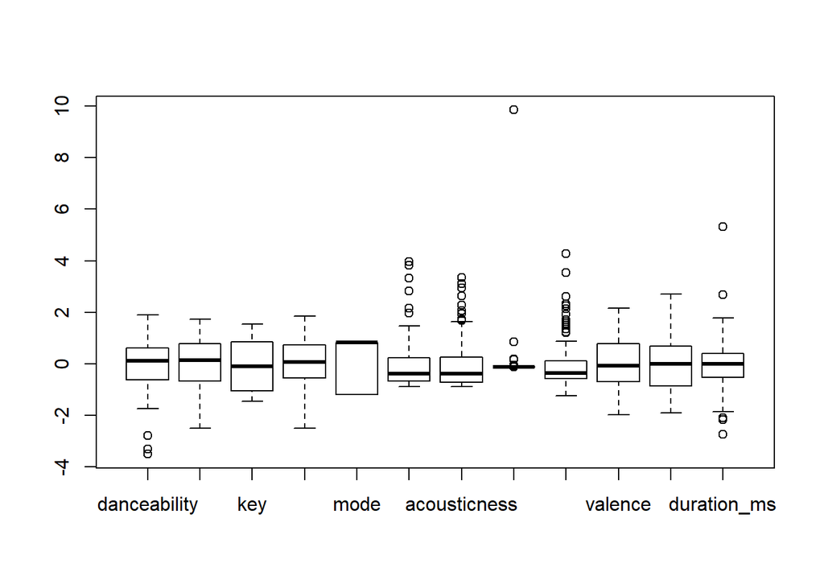

```r
boxplot(top_scale)
```

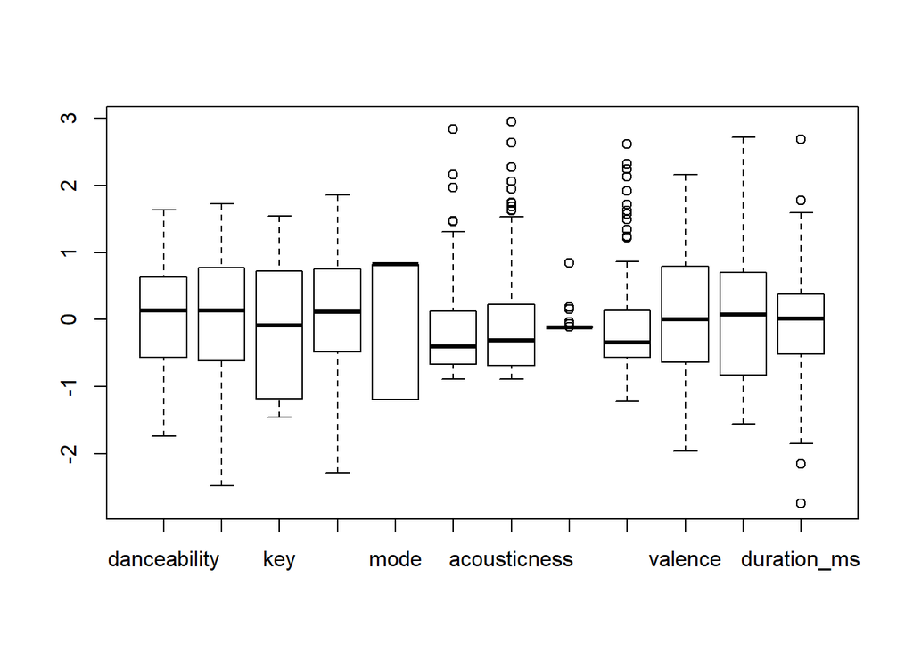

```r
top_df<-as.data.frame(top_scale)
top_df<-rownames_to_column(top_df,var='track')
filtr<-filter(top_df, danceability < -3 | speechiness > 3 | acousticness >3 | instrumentalness > 3 | liveness > 3 | duration_ms >3)
top_df<-column_to_rownames(top_df,var="track")
top_df2<-top_df[(top_df$danceability>-3)&(top_df$speechiness<3)&(top_df$acousticness<3)&(top_df$instrumentalness<3)&(top_df$liveness<3)&(top_df$duration_ms<3),]
boxplot(top_df2)
```

```r
summary(top_df2)
```

```
##   danceability          energy              key
##  Min.   :-1.73541   Min.   :-2.48202   Min.   :-1.44977
##  1st Qu.:-0.56809   1st Qu.:-0.61392   1st Qu.:-1.17777
##  Median : 0.13382   Median : 0.13745   Median :-0.08976
##  Mean   : 0.08333   Mean   : 0.06434   Mean   :-0.02252
##  3rd Qu.: 0.62974   3rd Qu.: 0.77854   3rd Qu.: 0.72624
##  Max.   : 1.63683   Max.   : 1.72293   Max.   : 1.54225
##     loudness             mode          speechiness       acousticness
##  Min.   :-2.28534   Min.   :-1.1936   Min.   :-0.8837   Min.   :-0.88446
##  1st Qu.:-0.48007   1st Qu.:-1.1936   1st Qu.:-0.6694   1st Qu.:-0.68615
##  Median : 0.11456   Median : 0.8294   Median :-0.4025   Median :-0.30642
##  Mean   : 0.08766   Mean   : 0.0566   Mean   :-0.1063   Mean   :-0.03057
##  3rd Qu.: 0.75645   3rd Qu.: 0.8294   3rd Qu.: 0.1285   3rd Qu.: 0.22312
##  Max.   : 1.85288   Max.   : 0.8294   Max.   : 2.8359   Max.   : 2.94777
##  instrumentalness      liveness           valence
##  Min.   :-0.11775   Min.   :-1.22514   Min.   :-1.963873
##  1st Qu.:-0.11775   1st Qu.:-0.55974   1st Qu.:-0.632772
##  Median :-0.11775   Median :-0.34302   Median : 0.007553
##  Mean   :-0.09758   Mean   :-0.03001   Mean   : 0.068904
##  3rd Qu.:-0.11557   3rd Qu.: 0.13163   3rd Qu.: 0.798258
##  Max.   : 0.84888   Max.   : 2.62129   Max.   : 2.166226
##      tempo             duration_ms
##  Min.   :-1.5585917   Min.   :-2.74295
##  1st Qu.:-0.8309207   1st Qu.:-0.51607
##  Median : 0.0725386   Median : 0.01353
##  Mean   : 0.0003765   Mean   :-0.03676
##  3rd Qu.: 0.6986328   3rd Qu.: 0.37708
##  Max.   : 2.7146432   Max.   : 2.68980
```

Po oczyszczeniu danych z obserwacji odstających, do dyspozycji mam 89 utworów. Wśród elementów, które musiałem usunąć, znalazł się utwór “God’s Plan” Drake’a. Najczęściej odtwarzana piosenka w 2018, która w chwili tworzenia projektu ma ponad 1,4 mld odsłuchań w serwisie, była outlierem ze względu na zbyt duży współczynnik **liveness**. Lista wszystkich wykluczonych obserwacji prezentuje się następująco ;

```
##                                       track danceability     energy
## 1                     1. Drake - God's Plan    0.2864115 -1.4480190
## 2          22. Nio Garcia - Te Bot? - Remix    1.4232074  0.1098801
## 3      24. 5 Seconds of Summer - Youngblood   -0.9190499  1.3437914
## 4                39. XXXTENTACION - changes   -0.3620962 -2.4199826
## 5     41. Eminem - River (feat. Ed Sheeran)    0.2406345  0.6199887
## 6             44. Imagine Dragons - Thunder   -0.8503844  1.1232039
## 7                       45. Reik - Me Niego    0.4618901  0.8267895
## 8  81. Billie Eilish - lovely (with Khalid)   -2.7882780 -2.5027029
## 9                 92. Lil Baby - Yes Indeed    1.8886071 -2.1580349
## 10            94. Keala Settle - This Is Me   -3.2994547  0.3097875
## 11   99. ZAYN - Dusk Till Dawn - Radio Edit   -3.4978218 -1.5307393
##            key   loudness       mode speechiness acousticness
## 1   0.45424291 -1.9877396  0.8294372  -0.0628450   -0.7354783
## 2   1.54224989  1.2560019 -1.1935804   0.9416801    1.5673422
```

[output cut: 21 more lines]

Dla pewności, przeprowadzę jeszcze test Grubbsa na obecność obserwacji odstających.

```
##
##  Grubbs test for one outlier
##
## data:  top_df_matrix
## G = 3.41166, U = 0.98908, p-value = 0.3341
## alternative hypothesis: highest value 2.94776722258385 is an outlier
```

```
##
##  Grubbs test for two opposite outliers
##
## data:  top_df_matrix
## G = 6.5932, U = 0.9796, p-value = 1
## alternative hypothesis: -2.74295321904181 and 2.94776722258385 are outliers
```

P-value przyjmuje wysokie (a w drugim przypadku wręcz bardzo wysokie wartości), co pokazuje, że oczyszczenie regułą 3 sigm spełniło swoje zadanie.

Pierwszą użytą przeze mnie techniką będzie metoda Warda, któa wykorzystuje analizę wariancji. Polega na minimalizowaniu sumy kwadratowych odchyleń skupień, i w większości przypadkóW dobrze się sprawdza, co przekłada się na jej dużą popularność.

Aby zaprezentować podział przy pomocy tej metody, należy utworzyć funkcję odległości, a następnie dendrogram.

```r
ward<-hclust(odl,method="ward.D2")
str(ward)
```

```
## List of 7
##  $ merge      : int [1:88, 1:2] -7 -20 -15 -32 -24 -16 -61 -2 -22 -66 ...
##  $ height     : num [1:88] 1.03 1.2 1.33 1.46 1.51 ...
##  $ order      : int [1:89] 17 78 42 81 25 52 83 29 16 35 ...
##  $ labels     : chr [1:89] "2. XXXTENTACION - SAD!" "3. Post Malone - rockstar (feat. 21 Savage)" "4. Post Malone - Psycho (feat. Ty Dolla $ign)" "5. Drake - In My Feelings" ...
##  $ method     : chr "ward.D2"
##  $ call       : language hclust(d = odl, method = "ward.D2")
##  $ dist.method: chr "euclidean"
##  - attr(*, "class")= chr "hclust"
```

```r
ward_d<-as.dendrogram(ward)
ward_d
```

```
## 'dendrogram' with 2 branches and 89 members total, at height 14.90293
```

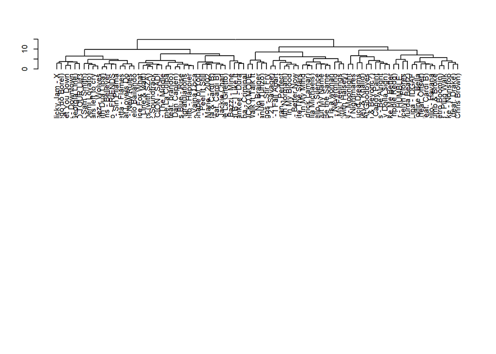

```r
par(mfrow=c(3,1))

plot(ward_d)
```

Teoretycznie wszystko działa, ale wykres nie prezentuje się zbyt atrakcyjnie. Odczytanie z niego czegokolwiek jest niemożliwe, należy więc podzielić dendrogram na kilka części.

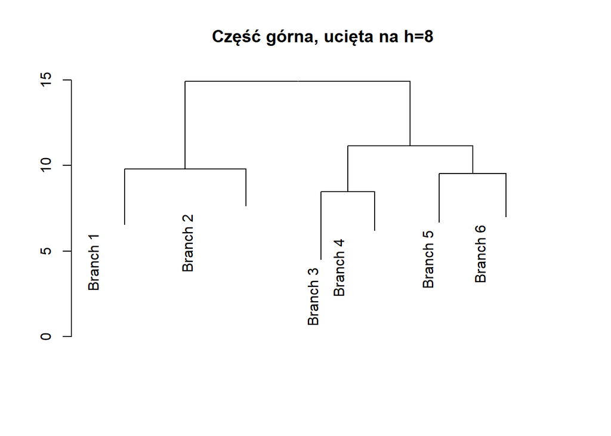

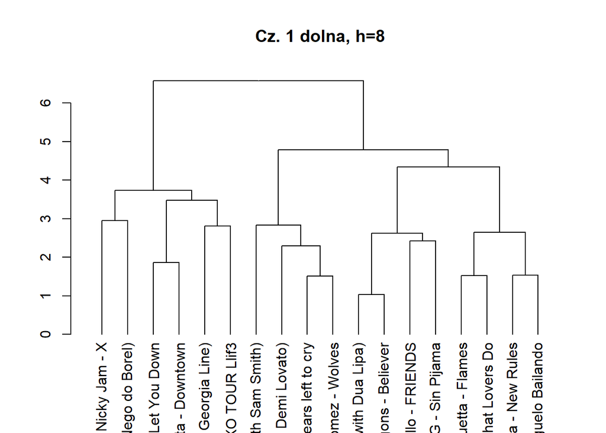

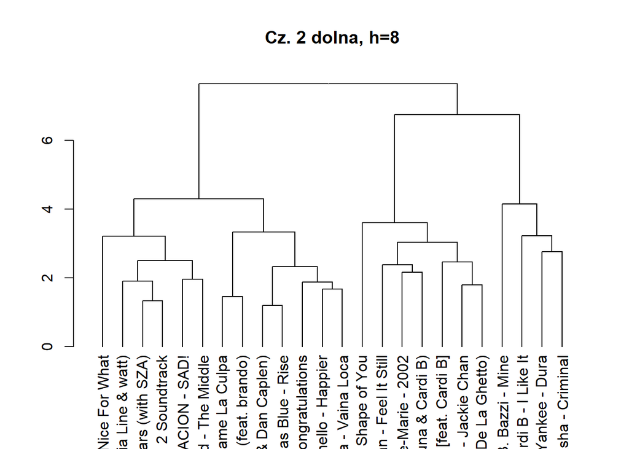